# 3M - 10 Years of Historical Price 01/09/2008 ~ 01/09/2018

SECTION 0 - OBTAIN AND TRANSFORMING DATA

3M CSV dataset

```r
dataset_MMM <- read.csv("MMM.csv")
head(dataset_MMM)
```

|  | Date | Open | High | Low | Close | Adj.Close | Volume |
| --- | --- | --- | --- | --- | --- | --- | --- |
| 1 | 2008-01-08 | 81.35 | 82.07 | 80.10 | 80.21 | 60.62685 | 5711200 |
| 2 | 2008-01-09 | 80.20 | 80.82 | 78.49 | 80.19 | 60.61175 | 6422300 |
| 3 | 2008-01-10 | 79.75 | 80.71 | 79.02 | 80.21 | 60.62685 | 6835800 |
| 4 | 2008-01-11 | 79.63 | 81.06 | 76.97 | 77.58 | 58.63898 | 8414500 |
| 5 | 2008-01-14 | 78.13 | 78.64 | 77.50 | 78.50 | 59.33435 | 2927600 |
| 6 | 2008-01-15 | 78.00 | 78.70 | 77.03 | 77.18 | 58.33664 | 4206500 |

```r
summary(dataset_MMM)
```

```
         Date           Open             High
 2008-01-08:   1   Min.   : 41.31   Min.   : 42.45
 2008-01-09:   1   1st Qu.: 81.26   1st Qu.: 81.83
 2008-01-10:   1   Median : 96.92   Median : 97.50
 2008-01-11:   1   Mean   :118.35   Mean   :119.20
 2008-01-14:   1   3rd Qu.:157.59   3rd Qu.:158.46
 2008-01-15:   1   Max.   :243.19   Max.   :244.23
 (Other)   :2513
      Low             Close          Adj.Close
 Min.   : 40.87   Min.   : 41.83   Min.   : 32.86
 1st Qu.: 80.50   1st Qu.: 81.22   1st Qu.: 66.41
 Median : 96.57   Median : 97.21   Median : 82.92
 Mean   :117.52   Mean   :118.42   Mean   :105.61
 3rd Qu.:156.73   3rd Qu.:157.65   3rd Qu.:145.32
 Max.   :239.18   Max.   :243.14   Max.   :238.47

     Volume
 Min.   :  651000
 1st Qu.: 2026100
 Median : 2782500
 Mean   : 3288103
 3rd Qu.: 3943750
 Max.   :16317000
```

C CSV dataset

```r
dataset_C <- read.csv("C.csv")
head(dataset_C)
```

|  | Date | Open | High | Low | Close | Adj.Close | Volume |
| --- | --- | --- | --- | --- | --- | --- | --- |
| 1 | 2008-09-02 | 196.3 | 198.2 | 188.8 | 191.1 | 182.3512 | 7979000 |
| 2 | 2008-09-03 | 191.2 | 196.6 | 187.7 | 196.1 | 187.1223 | 6362700 |
| 3 | 2008-09-04 | 193.0 | 194.7 | 182.1 | 183.0 | 174.6220 | 8057300 |
| 4 | 2008-09-05 | 180.5 | 191.8 | 179.3 | 190.7 | 181.9695 | 8401400 |
| 5 | 2008-09-08 | 208.4 | 209.5 | 195.0 | 203.2 | 193.8972 | 17043000 |
| 6 | 2008-09-09 | 200.2 | 203.8 | 188.1 | 188.8 | 180.1565 | 11634800 |

```r
summary(dataset_C)
```

```
         Date           Open             High
 2008-09-02:   1   Min.   : 10.20   Min.   : 10.70
 2008-09-03:   1   1st Qu.: 39.34   1st Qu.: 39.90
 2008-09-04:   1   Median : 47.60   Median : 48.00
 2008-09-05:   1   Mean   : 50.17   Mean   : 50.91
 2008-09-08:   1   3rd Qu.: 54.46   3rd Qu.: 54.95
 2008-09-09:   1   Max.   :231.60   Max.   :235.00
 (Other)   :2513
      Low             Close          Adj.Close
 Min.   :  9.70   Min.   : 10.20   Min.   :  9.747
 1st Qu.: 38.59   1st Qu.: 39.10   1st Qu.: 37.393
 Median : 47.07   Median : 47.56   Median : 45.603
 Mean   : 49.28   Mean   : 50.04   Mean   : 48.246
 3rd Qu.: 54.01   3rd Qu.: 54.48   3rd Qu.: 52.304
 Max.   :220.00   Max.   :230.00   Max.   :219.470

     Volume
 Min.   :  3998000
 1st Qu.: 16221050
 Median : 24164500
 Mean   : 32159178
 3rd Qu.: 39243400
 Max.   :377263800
```

PG CSV dataset

```r
dataset_PG <- read.csv("PG.csv")
head(dataset_PG)
```

|  | Date | Open | High | Low | Close | Adj.Close | Volume |
| --- | --- | --- | --- | --- | --- | --- | --- |
| 1 | 2008-09-02 | 70.35 | 71.43 | 70.15 | 70.47 | 51.39056 | 11255200 |
| 2 | 2008-09-03 | 70.42 | 71.50 | 70.18 | 71.42 | 52.08335 | 10433900 |
| 3 | 2008-09-04 | 71.16 | 71.52 | 70.37 | 70.44 | 51.36869 | 12298000 |
| 4 | 2008-09-05 | 70.39 | 71.07 | 69.73 | 70.78 | 51.61662 | 11578800 |
| 5 | 2008-09-08 | 71.33 | 72.48 | 71.31 | 72.37 | 52.77613 | 16521200 |
| 6 | 2008-09-09 | 71.66 | 72.46 | 71.47 | 71.89 | 52.42612 | 18542200 |

```r
summary(dataset_PG)
```

```
         Date           Open            High
 2008-09-02:   1   Min.   :44.51   Min.   :45.19
 2008-09-03:   1   1st Qu.:63.40   1st Qu.:63.80
 2008-09-04:   1   Median :76.39   Median :76.99
 2008-09-05:   1   Mean   :73.44   Mean   :73.93
 2008-09-08:   1   3rd Qu.:82.56   3rd Qu.:83.08
 2008-09-09:   1   Max.   :94.17   Max.   :94.67
 (Other)   :2513
      Low            Close         Adj.Close
 Min.   :39.37   Min.   :44.18   Min.   :32.65
 1st Qu.:62.97   1st Qu.:63.33   1st Qu.:49.97
 Median :75.81   Median :76.41   Median :66.62
 Mean   :72.96   Mean   :73.46   Mean   :63.62
 3rd Qu.:82.10   3rd Qu.:82.62   3rd Qu.:76.19
 Max.   :93.83   Max.   :94.40   Max.   :91.31

     Volume
 Min.   :  2196700
 1st Qu.:  7058250
 Median :  8970100
 Mean   : 10524215
 3rd Qu.: 11791750
 Max.   :123735700
```

GOOG CSV dataset

```r
dataset_GOOG <- read.csv("GOOG.csv")
head(dataset_GOOG)
```

|  | Date | Open | High | Low | Close | Adj.Close | Volume |
| --- | --- | --- | --- | --- | --- | --- | --- |
| 1 | 2008-09-02 | 236.8446 | 239.5321 | 229.2191 | 231.1218 | 231.1218 | 12302400 |
| 2 | 2008-09-03 | 232.8505 | 235.6126 | 228.3051 | 230.7045 | 230.7045 | 8685300 |
| 3 | 2008-09-04 | 228.5137 | 230.1233 | 223.2480 | 223.6752 | 223.6752 | 9759900 |
| 4 | 2008-09-05 | 221.3056 | 224.7681 | 218.6181 | 220.6896 | 220.6896 | 9127500 |
| 5 | 2008-09-08 | 224.5495 | 225.0065 | 207.4259 | 208.6181 | 208.6181 | 18153000 |
| 6 | 2008-09-09 | 210.2177 | 214.7930 | 206.1591 | 207.9773 | 207.9773 | 14553100 |

```r
summary(dataset_GOOG)
```

```
         Date           Open             High
 2008-09-02:   1   Min.   : 130.4   Min.   : 133.8
 2008-09-03:   1   1st Qu.: 285.6   1st Qu.: 287.6
 2008-09-04:   1   Median : 444.0   Median : 446.0
 2008-09-05:   1   Mean   : 515.8   Mean   : 520.1
 2008-09-08:   1   3rd Qu.: 722.8   3rd Qu.: 727.3
 2008-09-09:   1   Max.   :1271.0   Max.   :1273.9
 (Other)   :2513
      Low             Close          Adj.Close
 Min.   : 122.9   Min.   : 127.9   Min.   : 127.9
 1st Qu.: 282.7   1st Qu.: 286.0   1st Qu.: 286.0
 Median : 440.2   Median : 442.6   Median : 442.6
 Mean   : 511.2   Mean   : 515.8   Mean   : 515.8
 3rd Qu.: 716.5   3rd Qu.: 720.8   3rd Qu.: 720.8
 Max.   :1249.0   Max.   :1268.3   Max.   :1268.3

     Volume
 Min.   :    7900
 1st Qu.: 1657600
 Median : 3445800
 Mean   : 4289452
 3rd Qu.: 5423650
 Max.   :32690500
```

MYL CSV dataset

```r
dataset_MYL <- read.csv("MYL.csv")
head(dataset_MYL)
```

|  | Date | Open | High | Low | Close | Adj.Close | Volume |
| --- | --- | --- | --- | --- | --- | --- | --- |
| 1 | 2008-09-02 | 12.89 | 13.14 | 12.68 | 12.83 | 12.83 | 5319000 |
| 2 | 2008-09-03 | 12.84 | 12.90 | 12.60 | 12.87 | 12.87 | 5851400 |
| 3 | 2008-09-04 | 12.82 | 13.01 | 12.66 | 12.84 | 12.84 | 5865200 |
| 4 | 2008-09-05 | 12.72 | 12.84 | 12.46 | 12.50 | 12.50 | 3865900 |
| 5 | 2008-09-08 | 12.69 | 12.80 | 12.33 | 12.42 | 12.42 | 3591700 |
| 6 | 2008-09-09 | 11.80 | 12.45 | 10.93 | 11.10 | 11.10 | 28487100 |

```r
summary(dataset_MYL)
```

```
         Date           Open            High
 2008-09-02:   1   Min.   : 5.98   Min.   : 6.25
 2008-09-03:   1   1st Qu.:20.92   1st Qu.:21.12
 2008-09-04:   1   Median :32.10   Median :32.64
 2008-09-05:   1   Mean   :33.14   Mean   :33.58
 2008-09-08:   1   3rd Qu.:43.97   3rd Qu.:44.57
 2008-09-09:   1   Max.   :75.40   Max.   :76.69
 (Other)   :2513
      Low            Close         Adj.Close
 Min.   : 5.75   Min.   : 5.77   Min.   : 5.77
 1st Qu.:20.60   1st Qu.:20.89   1st Qu.:20.89
 Median :31.80   Median :32.13   Median :32.13
 Mean   :32.66   Mean   :33.12   Mean   :33.12
 3rd Qu.:43.02   3rd Qu.:43.80   3rd Qu.:43.80
 Max.   :73.63   Max.   :76.06   Max.   :76.06

     Volume
 Min.   :  856200
 1st Qu.: 3795500
 Median : 5237900
 Mean   : 6130334
 3rd Qu.: 7200400
 Max.   :50917600
```

Retrieve the daily closing price

```r
# Initialize date column for analyze purpose
# close_price$date = dataset_MMM$Date
close_price$MMM = dataset_MMM$Close
close_price$C = dataset_C$Close
close_price$PG = dataset_PG$Close
close_price$GOOG = dataset_GOOG$Close
close_price$MYL = dataset_MYL$Close
#Show several example of each asset's close price
head(close_price$MMM)
```

```
[1] 80.21 80.19 80.21 77.58 78.50 77.18
```

```r
head(close_price$C)
```

```
[1] 191.1 196.1 183.0 190.7 203.2 188.8
```

```r
head(close_price$PG)
```

```
[1] 70.47 71.42 70.44 70.78 72.37 71.89
```

```r
head(close_price$GOOG)
```

```
[1] 231.1218 230.7045 223.6752 220.6896 208.6181 207.9773
```

```r
head(close_price$MYL)
```

```
[1] 12.83 12.87 12.84 12.50 12.42 11.10
```

Construct the log daily returns of each asset

```r
# Initialize date column for analyze purpose
returns$MMM = diff(log(close_price$MMM), lag = 1)
returns$C = diff(log(close_price$C), lag = 1)
returns$PG = diff(log(close_price$PG), lag = 1)
returns$GOOG = diff(log(close_price$GOOG), lag = 1)
returns$MYL = diff(log(close_price$MYL), lag = 1)
#Show several example of each asset's close price
head(returns$MMM)
```

```
[1] -0.0002493392  0.0002493392 -0.0333384951  0.0117889370
[5] -0.0169582687  0.0015536383
```

```r
head(returns$C)
```

```
[1]  0.02582788 -0.06913861  0.04121534  0.06348920 -0.07350243
[6] -0.01064973
```

```r
head(returns$PG)
```

```
[1]  0.013390813 -0.013816602  0.004815149  0.022215430
[5] -0.006654731  0.006930995
```

```r
head(returns$GOOG)
```

```
[1] -0.001807161 -0.030942593 -0.013437720 -0.056251814
[5] -0.003076484 -0.010806750
```

```r
head(returns$MYL)
```

```
[1]  0.003112843 -0.002333723 -0.026836654 -0.006420568
[5] -0.112362968  0.032789823
```

Insert the result into data frame format

```r
transformed_data.close <- data.frame(close_price$date, close_price$MMM, close_price$C, close_price$PG, close_price$GOOG, close_price$MYL)
str(transformed_data.close)
```

```
'data.frame':   2519 obs. of  6 variables:
 $ close_price.date: Factor w/ 2519 levels "2008-01-08","2008-01-09",..: 1 2 3 4 5 6 7 8 9 10 ...
 $ close_price.MMM : num  80.2 80.2 80.2 77.6 78.5 ...
 $ close_price.C   : num  191 196 183 191 203 ...
 $ close_price.PG  : num  70.5 71.4 70.4 70.8 72.4 ...
 $ close_price.GOOG: num  231 231 224 221 209 ...
 $ close_price.MYL : num  12.8 12.9 12.8 12.5 12.4 ...
```

```r
n <- nrow(transformed_data.close)
returns$date <- returns$date[2:n]
transformed_data.returns <- data.frame(returns$date, returns$MMM, returns$C, returns$PG, returns$GOOG, returns$MYL)
str(transformed_data.returns)
```

```
'data.frame':   2518 obs. of  6 variables:
 $ returns.date: Factor w/ 2519 levels "2008-01-08","2008-01-09",..: 2 3 4 5 6 7 8 9 10 11 ...
 $ returns.MMM : num  -0.000249 0.000249 -0.033338 0.011789 -0.016958 ...
 $ returns.C   : num  0.0258 -0.0691 0.0412 0.0635 -0.0735 ...
 $ returns.PG  : num  0.01339 -0.01382 0.00482 0.02222 -0.00665 ...
 $ returns.GOOG: num  -0.00181 -0.03094 -0.01344 -0.05625 -0.00308 ...
 $ returns.MYL : num  0.00311 -0.00233 -0.02684 -0.00642 -0.11236 ...
```

SECTION 1 - EXPLORATORY DATA ANALYSIS

Generate a time plot series of closing price on the same graph

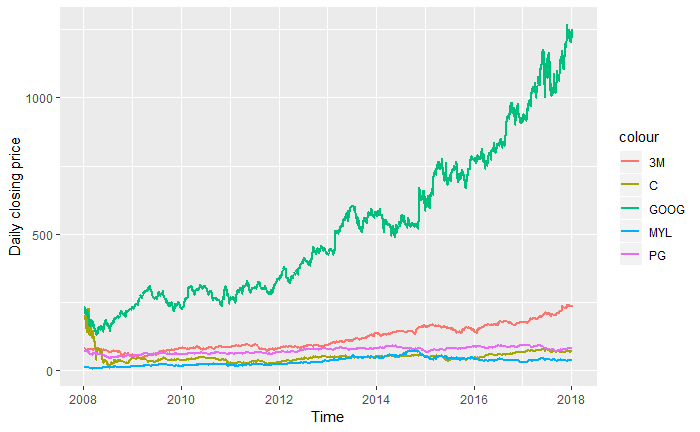

```r
# Load necessary packages
library(tidyverse)
library(ggplot2)
# View time plot of the closing price of 3M
 ggplot(data = transformed_data.close,
        aes(x=as.Date(close_price$date), y=value, group=1) ) +
        geom_line(aes(y=close_price$MMM, col='3M'), size = 1) +
        geom_line(aes(y=close_price$C, col='C'), size = 1) +
        geom_line(aes(y=close_price$PG, col='PG'), size = 1) +
        geom_line(aes(y=close_price$GOOG, col='GOOG'), size = 1) +
        geom_line(aes(y=close_price$MYL, col='MYL'), size = 1) +
        labs(x = "Time", y = "Daily closing price")
```

Discussion: (Surya) By looking at the daily closing price in 10 years from 2008 to 2018, I could see that the growth of the close price for GOOG (Alphabet Inc.) was positively growth over time. Initially, C (Citigroup Inc.) has a similar close price in 2008. However, their got a negative trend from early 2008 to mid 2008 which made them stuck for years ahead. Interestingly, even though the MMM (3M Company)’s performance was overshadowed with GOOG, they enjoyed quite a positive trend. The 3 others assets have a similar stagnant closing price over time.

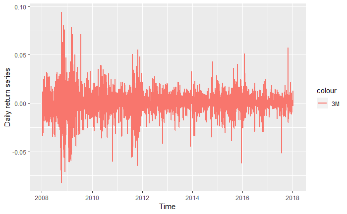

```r
# View time plot of the closing price
 ggplot(data = transformed_data.returns,
        aes(x=as.Date(returns$date), y=value, group=1) ) +
        geom_line(aes(y=returns$MMM, col='3M'), size = 1) +
        labs(x = "Time", y = "Daily return series")
```

Discussion: (Surya)

The average value of 3M asset over 10 years was quite stable where the mean of log return is almost zero. However, the volatility becomes larger for quite a long time at the end of 2008 and at the end of 2011; for a short time at the end of 2015 and mid 2017.